# Final Project- Investment in Resort Hotels on the West Coast of California

Akshaya Kannapiran

Fall 2021

### Project Description

#### Introduction

This project will give you an opportunity to apply many of the data analytical techniques covered in class. It will also allow you to work with a comprehensive data set collected from a real business context. In this project, you will have a chance to showcase your analytical techniques as well as decision-making skills on a new business problem. As the outcome of this project, you will make business decisions that are informed by your data analyses.

#### Major Objective and The Data

You are a business consultant. An important client of yours has invested in a couple of resort hotels on the West Coast of California. The client wants to better understand the performance of the resort hotels. She has gathered data on 200 hotels in the area. The data are contained in the “hotels.csv” data file, which is posted on the course website. The variables include: 1. ID – the resort hotel ID, which is the unique IDs of the hotels 2. Year – this describes the year when the hotel started its business 3. Shuttle – whether the hotel has free airport shuttle service (coded as 1) or not (coded as 0). 4. Price – this is the average price per room night (in $) 5. Ads – this is the yearly advertising expenditure (in thousands of $ dollars) 6. View – this is the number of ocean-view rooms the hotel has 7. Food – the number of eateries (e.g., restaurants, cafes, or bars) in the hotel 8. Rating – this is a rating of the overall hotel service, a scale from 1 (very poor) to 10 (very good). 9. Positioning – whether the hotel positions or markets itself as family-styled (coded as 0) or business-oriented (coded as 1) 10. Room.Book – this measures the number of times rooms are booked per week. This indicates the volume of guests and is a key measure of success/revenues in hotel business. Your client would like you to help her interpret and eventually predict the room-book in the area as close to reality as possible. She also wants to know whether the data can help her determine what can be done to improve room-book.

#### Task Overview

First, randomly select a subset of the 200 hotels. This random sample should contain 170 hotels. Create a data frame of this sample and call it “hotel.training” (i.e., the training set). Create another data frame of the rest of the hotels (n = 30) and call it “hotel.testing” (i.e., the testing set). Make sure you save and export your training and testing sets at the very beginning of your work. Both sets need to be submitted along with your final report. You can read “A conceptual note on the project procedure” in the appendix for more information.

Second, use multiple regression to explain room-book. Your goal is to find which variables influence room-book as part of a multiple regression model. You will interpret the results of the model and use it for predictions on the testing set.

Lastly, you need to make prediction using the data in the testing set. Based on your prediction, you need to make the decision on “which 10 hotels ranked highest in room-book”. Then validate your prediction using the real room-book values in the testing set. Discuss your predictions (i.e., answer the specific questions below; see “Specific Requirements in the Project Report”).

### Data Preparation

```r
library(tidyverse)
library(knitr)
library(dplyr)
hotel <- read.csv("hotels.csv", header = TRUE)
```

```r
#Generating random samples
#hotel.training <- sample_n(hotel, 170)
#hotel.testing <- filter(hotel, !(ID%in%hotel.training$ID))
#save the two random samples so it does not regenerate data
#write.csv(hotel.training,file ="hotel.training.csv", sep = ",")
#write.csv(hotel.testing, file = "hotel.testing.csv", sep = ",")
```

Inputting the random sample values back in hotel.testing and hotel.training data frame.

```r
hotel.training <- read.csv("hotel.training.csv", header = TRUE)
hotel.testing <- read.csv("hotel.testing.csv", header = TRUE)
```

### [Using the training set]:

### Problem 1:

##### (a) In the sample, how many hotels position or market themselves as family-styled?

```r
family_style <- hotel.training$Positioning
sum(family_style < 1)
```

```
## [1] 69
```

##### (b) How many position themselves as business-oriented?

```r
sum(family_style > 0)
```

```
## [1] 101
```

Result: There are 69 family styled hotels and 101 business- oriented hotels.

##### (c)Is there a significant difference in room-book between hotels who are marketed as family-styled versus business-oriented?

```r
hotel.lm <- lm(Room.Book ~ Positioning, data = hotel.training)
summary(hotel.lm)
```

```
##
## Call:
## lm(formula = Room.Book ~ Positioning, data = hotel.training)
##
## Residuals:
##      Min       1Q   Median       3Q      Max
## -194.638  -64.638    1.584   61.584  171.584
##
## Coefficients:
##             Estimate Std. Error t value Pr(>|t|)
## (Intercept)  204.638      9.867  20.741   <2e-16 ***
## Positioning  -16.222     12.801  -1.267    0.207
## ---
## Signif. codes:  0 '***' 0.001 '**' 0.01 '*' 0.05 '.' 0.1 ' ' 1
##
## Residual standard error: 81.96 on 168 degrees of freedom
## Multiple R-squared:  0.009469,   Adjusted R-squared:  0.003573
## F-statistic: 1.606 on 1 and 168 DF,  p-value: 0.2068
```

Results: The p-value is greater than 0.05. So, it’s not significant.

##### (d) Also use a side-by- side boxplot to present the room-book of the two types of hotels.

```r
tb <- mutate(hotel.training, Positioning = as.factor(Positioning))
levels(tb$Positioning) <- c("Family-style" , "Business Oriented")
class(tb$Positioning)
```

```
## [1] "factor"
```

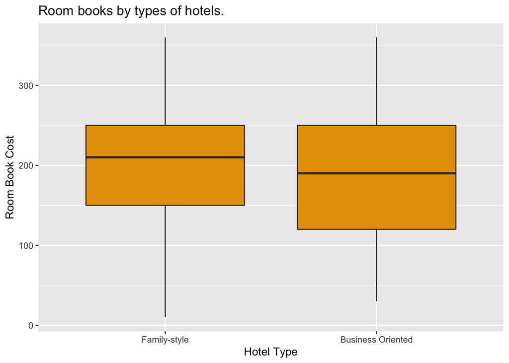

```r
boxplot <- ggplot(tb, aes(Positioning,Room.Book)) +
                  geom_boxplot(fill = "#E69F00") +
                  labs(title = "Room books by types of hotels.",
                       x = "Hotel Type",
                       y = "Room Book Cost")
boxplot
```

### Problem 2:

##### Create a new variable “age” (i.e., you can just create a new data frame which has one variable), which is the age of the hotels in 2021. Report the mean, standard deviation, maximum, and minimum of the age variable. In addition, present a histogram of the age variable.

```r
age <- 2021 - (hotel.training$Year)
```

```r
hotels_stats <- summarize(hotel.training,
                          mean = mean(age),
                          sd = sd(age),
                          max = max(age),
                          min = min(age))
kable(round(hotels_stats, digits = 3))
```

| mean | sd | max | min |
| --- | --- | --- | --- |
| 20.888 | 8.38 | 39 | 8 |

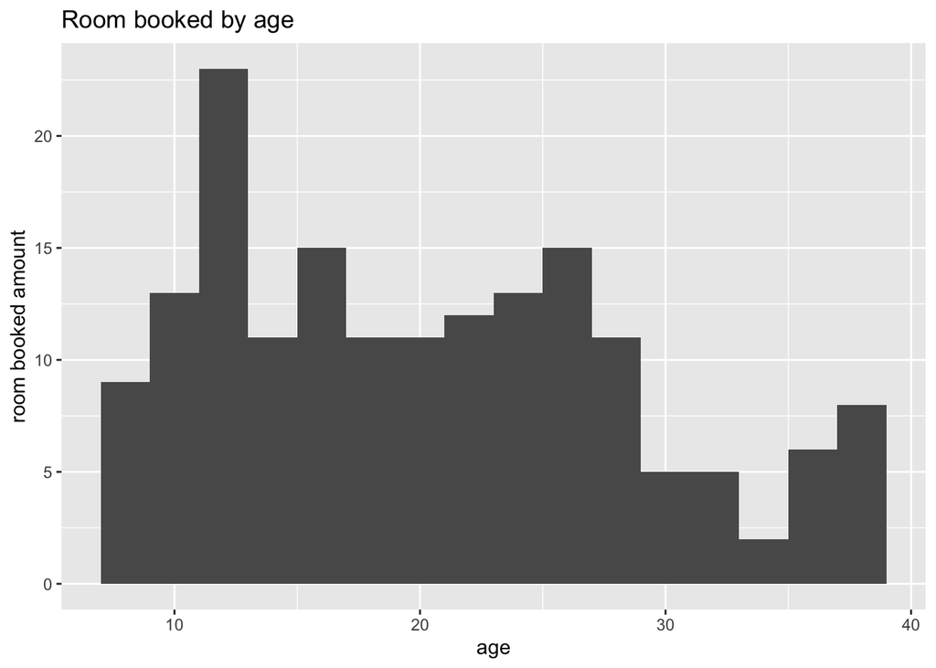

```r
histogram <- ggplot(hotel.training,aes(x = age))+
  geom_histogram(binwidth = 2) +
  labs(title = "Room booked by age",
       x = "age",
       y = "room booked amount")
histogram
```

### Regression Modeling and Interpretations

### Problem 3:

##### Fit a regression model to explain hotel room-book.

```r
hotels.lm <- lm(Room.Book ~ Year + Shuttle + Price + Ads + View + Food + Rating + Positioning, data = hotel.training)
lm.results <- summary(hotels.lm)
lm.coeff <- lm.results$coefficients
lm.coeff
```

```
##                  Estimate   Std. Error    t value     Pr(>|t|)
## (Intercept) -716.47492292 8.728815e+02 -0.8208158 4.129649e-01
## Year           0.36677902 4.345729e-01  0.8439989 3.999223e-01
## Shuttle        4.15920045 1.103008e+01  0.3770780 7.066122e-01
## Price         -0.19198312 1.227250e-01 -1.5643354 1.197023e-01
## Ads            0.08142433 7.248681e-03 11.2329865 5.510242e-22
## View           3.47620854 2.965331e-01 11.7228364 2.445859e-23
## Food           2.96914323 3.028067e+00  0.9805408 3.282904e-01
## Rating        11.45877437 2.670901e+00  4.2902276 3.069537e-05
## Positioning   -7.72412614 7.675225e+00 -1.0063714 3.157471e-01
```

```r
kable(lm.coeff)
```

|  | Estimate | Std. Error | t value | Pr(>\|t\|) |
| --- | --- | --- | --- | --- |
| (Intercept) | -716.4749229 | 872.8814641 | -0.8208158 | 0.4129649 |
| Year | 0.3667790 | 0.4345729 | 0.8439989 | 0.3999223 |
| Shuttle | 4.1592004 | 11.0300788 | 0.3770780 | 0.7066122 |
| Price | -0.1919831 | 0.1227250 | -1.5643354 | 0.1197023 |
| Ads | 0.0814243 | 0.0072487 | 11.2329865 | 0.0000000 |
| View | 3.4762085 | 0.2965331 | 11.7228364 | 0.0000000 |
| Food | 2.9691432 | 3.0280669 | 0.9805408 | 0.3282904 |
| Rating | 11.4587744 | 2.6709013 | 4.2902276 | 0.0000307 |
| Positioning | -7.7241261 | 7.6752245 | -1.0063714 | 0.3157471 |

The results show that we should remove the Year,Shuttle,Price,Food,Positioning, as it is not significant predictor given that it’s p-values, which is much higher than 0.05. We will have to update the regression model.

```r
hotels.lm.updated <- lm(Room.Book ~ Ads+View+Rating, data = hotel.training)
lm.results.updated <- summary(hotels.lm.updated)
lm.coeff2 <- lm.results.updated$coefficients
kable(lm.coeff2)
```

|  | Estimate | Std. Error | t value | Pr(>\|t\|) |
| --- | --- | --- | --- | --- |
| (Intercept) | -38.6074027 | 18.0198130 | -2.142497 | 0.0336109 |
| Ads | 0.0826697 | 0.0071108 | 11.625983 | 0.0000000 |
| View | 3.4303483 | 0.2920053 | 11.747557 | 0.0000000 |
| Rating | 12.7759298 | 2.5176423 | 5.074561 | 0.0000010 |

#### Assess the model

```r
lm.results.updated$r.squared
```

```
## [1] 0.6902659
```

```r
lm.results.updated$adj.r.squared
```

```
## [1] 0.6846683
```

### [Using the testing set]:

### Prediction and Validation

### Problem 5:

##### Based on your regression results, predict which 10 hotels in the testing set ranked highest in room-book. Clearly state your answer in the report (i.e., the 10 hotel IDs).

```r
hotel.lm.samp <- lm(Room.Book ~ Year + Price + Ads + View + Rating, data = hotel.training)
testing.prediction <- predict(hotel.lm.samp, data.frame(hotel.testing))
testing.prediction
```

```
##         1         2         3         4         5         6         7         8
## 220.03998 219.71259 203.28801 212.36143 151.46128  92.93878 242.38151 219.50696
##         9        10        11        12        13        14        15        16
## 119.93468 156.69579 211.21957 129.89176  50.98327 142.60918 219.18512 133.70236
##        17        18        19        20        21        22        23        24
##  88.51960 218.65136 104.63882 212.58687 187.68849 207.74164 192.23596 270.78298
##        25        26        27        28        29        30
## 142.70888 216.56407 233.99251 173.87388 188.43866 226.26137
```

```r
hotel.testing.prediction <- transmute(hotel.testing,
                                      ID = ID,
                                      Room.Book = testing.prediction,
                                      Price = Price,
                                      Ads = Ads,
                                      View = View,
                                      Rating = Rating)
```

##### To see what variables led to high booking

```r
hotel.testing.num <- hotel.testing.prediction[order(-hotel.testing.prediction$Room.Book), ]
hotel.10.pred <- head(hotel.testing.num,10)
kable(hotel.10.pred)
```

|  | ID | Room.Book | Price | Ads | View | Rating |
| --- | --- | --- | --- | --- | --- | --- |
| 24 | 148 | 270.7830 | 350 | 1294.099 | 38 | 7 |
| 7 | 56 | 242.3815 | 295 | 1112.470 | 28 | 7 |
| 27 | 164 | 233.9925 | 360 | 9.104 | 53 | 8 |
| 30 | 198 | 226.2614 | 285 | 800.615 | 34 | 6 |
| 1 | 2 | 220.0400 | 330 | 985.685 | 28 | 7 |
| 2 | 5 | 219.7126 | 325 | 574.513 | 44 | 5 |
| 8 | 70 | 219.5070 | 275 | 566.501 | 32 | 8 |
| 15 | 98 | 219.1851 | 265 | 746.024 | 34 | 6 |
| 18 | 112 | 218.6514 | 345 | 426.784 | 37 | 8 |
| 26 | 163 | 216.5641 | 285 | 883.877 | 26 | 7 |

Interpretation: The 10 hotels in the testing set ranked highest in room-book are Hotel-ID 148,56,164,198,2,5,70,98,112,163.

### Problem 6:

##### Validate your prediction using the real room-book values in the testing set: Is your prediction correct? That is, are the 10 predicted hotels really ranked highest? How many of your predicted top 10s are actually in the top 10?

```r
#reordering the rooms booked
hotel.trans <- transmute(hotel.testing,
                         ID = ID,
                         Room.Book = Room.Book,
                         Price = Price,
                         Ads = Ads,
                         View = View,
                         Rating = Rating)
hotel.trans
```

```
##     ID Room.Book Price      Ads View Rating
## 1    2       120   330  985.685   28      7
## 2    5       220   325  574.513   44      5
## 3   18       210   280  196.650   36      8
## 4   22       230   290  957.167   28      6
## 5   47        40   350  102.568   25      8
## 6   52       190   280  405.913   12      4
## 7   56       210   295 1112.470   28      7
## 8   70       240   275  566.501   32      8
## 9   71       160   290  102.568   26      5
## 10  73       140   275   68.594   28      7
## 11  74       210   335  642.786   32      7
## 12  78       160   260   51.229   19      7
## 13  82        70   250  256.894    1      4
## 14  89       120   280  135.986   22      7
```

[output cut: 16 more lines]

```r
hotel.test.order <- hotel.trans[order(-hotel.trans$Room.Book), ]
hotel.10.pred2 <- head(hotel.trans,10)
hotel.10.pred3 <- transmute(hotel.10.pred2,
                            ID = ID,
                            Room.book = Room.Book)

hotel.predict <- transmute(hotel.10.pred,
                           ID =ID,
                           Room.Book = Room.Book)
hotel.10.pred2
```

```
##    ID Room.Book Price      Ads View Rating
## 1   2       120   330  985.685   28      7
## 2   5       220   325  574.513   44      5
## 3  18       210   280  196.650   36      8
## 4  22       230   290  957.167   28      6
## 5  47        40   350  102.568   25      8
## 6  52       190   280  405.913   12      4
## 7  56       210   295 1112.470   28      7
## 8  70       240   275  566.501   32      8
## 9  71       160   290  102.568   26      5
## 10 73       140   275   68.594   28      7
```

```r
prediction.hotel <- hotel.10.pred$ID
prediction.hotel1<- hotel.10.pred2$ID
setdiff(prediction.hotel,prediction.hotel1)
```

```
## [1] 148 164 198  98 112 163
```

```r
which(prediction.hotel %in% prediction.hotel1)
```

```
## [1] 2 5 6 7
```

```r
#match the ID
hotel.10.pred2$ID[match(hotel.10.pred$ID, hotel.10.pred2$ID)]
```

```
##  [1] NA 56 NA NA  2  5 70 NA NA NA
```

```r
#to find how many predicted top 10
length(which(prediction.hotel %in% prediction.hotel1))
```

```
## [1] 4
```

- End -